# 二手车保值比率影响因素分析

狗熊会

案例难度：***

随着我国消费者消费观念的转变，购车族对于二手车的接受度和需求度大大提高，持续拉动二手车市场的发展。同时，二手车电商市场的不断升级，消费者可以直接通过电脑来选择自己满意的品牌车型，并且能直接在网上与店家谈价，进一步提高了汽车的流通速度。

谈及二手车市场，保值率可以说同时牵动买车方、卖车方、中间交易商和汽车制造商的心，那到底什么是影响二手车保值率的关键因素呢？相关方又应该如何利用这些因素，达成称心如意的二手车交易呢？本案例通过分析探究二手车的基本属性、使用状况、动力情况和内外部配置等相关因素对其保值比率的影响，并建立线性回归模型，获得影响二手车保值比率的关键因素，为各相关方提供宝贵建议。

学习目标：

1. 了解二手车保值比率相关数据；

2. 对数据进行简单处理和描述分析；

3. 对不同属性进行交互分析。

4. 建立线性回归模型并选择变量。

## 任务一

设置好工作路径后读入二手车数据cars.csv，命名为dat0，查看数据的行数和列数。由于存在一些没有采集到关键变量的数据，而这类数据不纳入后续分析和回归建模，因此提前删除，处理后的数据命名更新后，查看数据总量。

没有采集到的关键变量特征为：

- **pailiang = -1**
- **paifang = -1**

```
## [1] 12951    19
```

```
## [1] 12820
```

## 任务二

绘制汽车保值率和Log-保值比率的直方图，观察数据特征，并进行简要解读（可以关注最大、最小值分别是什么类型的汽车呢？）。

注意：保值率 = 报价/原价；Log-保值比率 = Log(报价/(原价 - 报价))

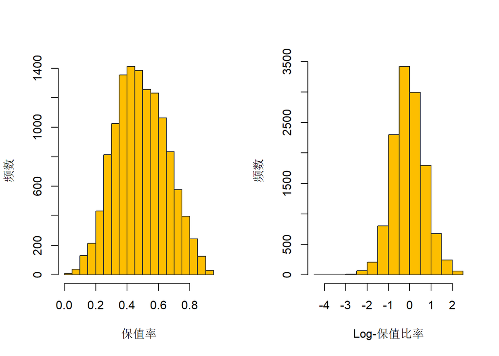

## 任务三

汽车的动力情况中，排放标准和排量情况对其保值比率是否有影响呢？绘制这两个变量对Log-保值比率的箱线图，探究它们之间的关系，并给出你的解读。

注意：

- 不同类型的排放标准可以进行合并，保留你认为较为合适的变量水平；
- 汽车的排量（单位：L）情况划分为：微型轿车的排量小于1L；普通级轿车的排量为[1.0, 1.6)；中级轿车的排量为[1.6, 2.5)；中高级轿车的排量为[2.5, 4.0)；高级轿车的排量则大于等于4.0L。

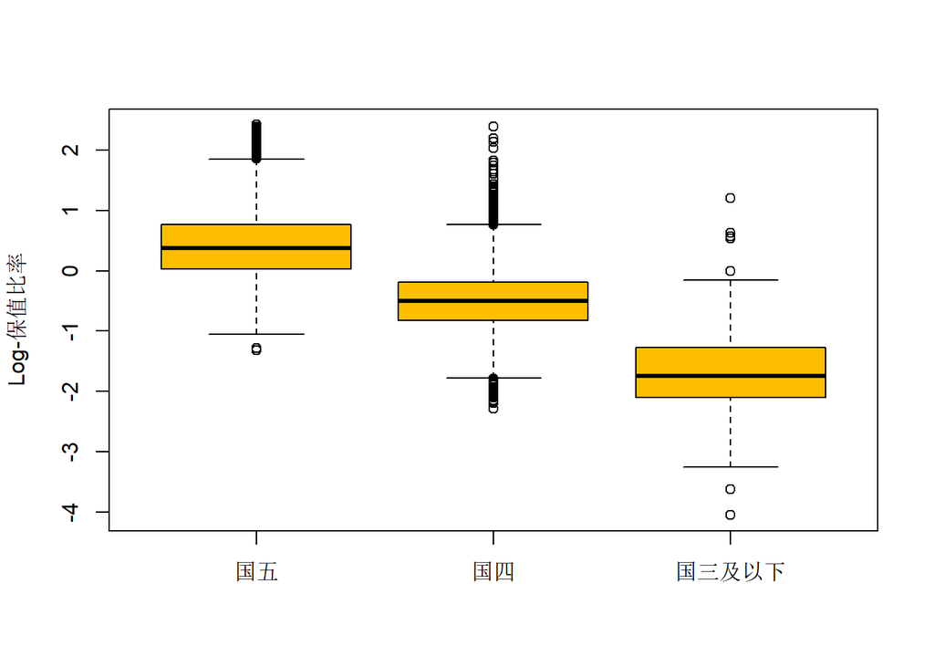

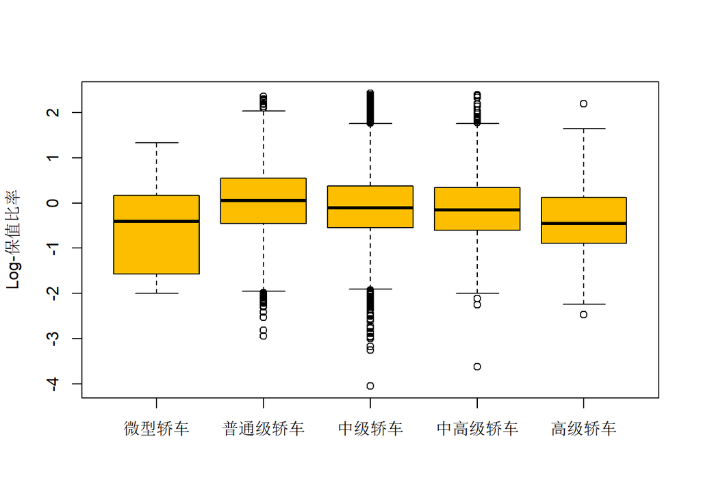

## 任务四

根据描述分析，发现不同车身类型、不同汽车厂商的保值比率也各有所差异。进而我们想知道，不同汽车厂商的二手车中，车身类型对保值比率的影响是不同的吗？找到数据cars-final.csv，读入后命名为dat，这个数据文件对多分类变量已经进行了哑变量处理。对车身类型和汽车厂商进行交互分析，绘制箱线图，尝试给出解读。

注意：由于汽车厂商类型较多，在本数据中选择样本量较多的几种，其余的厂商合并为其他厂商。

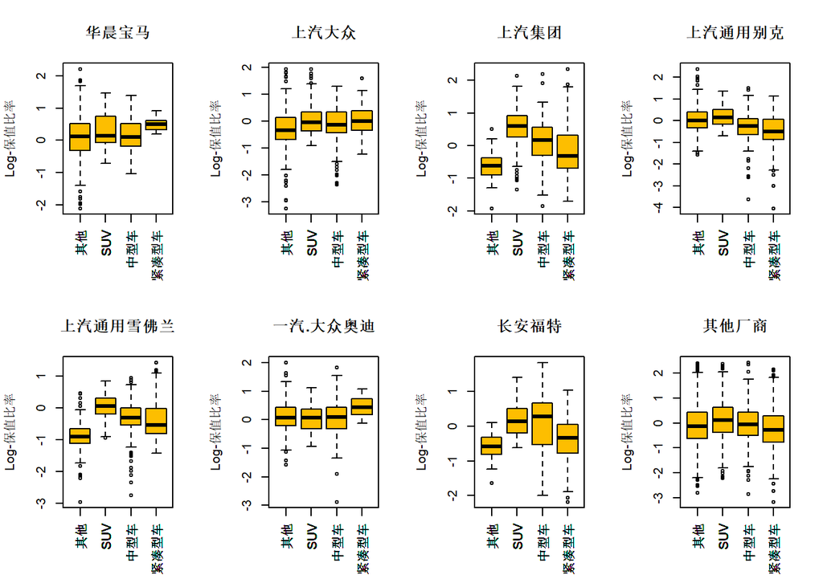

## 任务五

在任务四的结果中，我们可以看出汽车厂商和车身类型交互影响的作用是不可忽视的。此外，连续变量里程对汽车的保值比率影响又是如何的呢？绘制散点图，发现其中的规律。

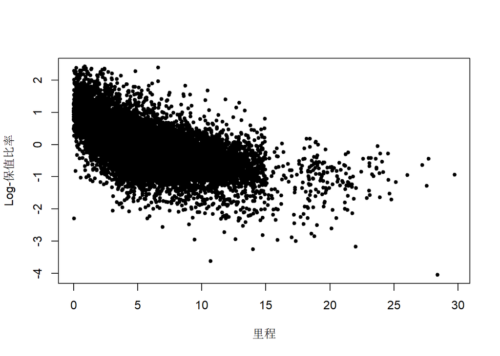

## 任务六

为了更准确地衡量各因素对二手车保值比率的影响，下面以log-保值比率为因变量建立线性回归模型。使用任务四读入的数据dat，将分类变量转换为因子型。在建模时，需要考虑任务四和任务五的结论，加入**汽车厂商&车身类型交互项**和**里程的二次项**。对全模型进行逐步回归筛选变量。得到的最终模型应如下所示。在得到模型后，尝试对汽车厂商&车身类型交互项和其他你感兴趣的变量给出解读。

提示：使用BIC准则选择模型。

```
##
## Call:
## lm(formula = ratio ~ shangpaishijian + licheng + biansu + zhouju +
##     tianchuang1 + tianchuang2 + zhenpizuoyi + daocheyingxiang +
##     daocheleida + GPS + SUV + 紧凑型车 + 中大型车 + 中型车 +
##     国四 + 国五 + 普通级轿车 + 中高级轿车 + 中级轿车 + 华晨宝马 +
##     上汽大众 + 上汽集团 + 上汽通用雪佛兰 + 一汽.大众奥迪 + 长安福特 +
##     licheng2 + 上汽大众_SUV + 上汽集团_SUV + 上汽通用雪佛兰_SUV +
##     长安福特_SUV + 其他厂商_SUV + 上汽大众_紧凑型车 + 上汽集团_紧凑型车 +
##     上汽通用雪佛兰_紧凑型车 + 长安福特_紧凑型车 + 其他厂商_紧凑型车 +
##     上汽大众_中型车 + 上汽集团_中型车 + 上汽通用雪佛兰_中型车 +
##     长安福特_中型车 + 其他厂商_中型车, data = dat3)
##
## Residuals:
##      Min       1Q   Median       3Q      Max
## -2.21834 -0.26064 -0.02481  0.22462  2.40032
##
## Coefficients:
##                           Estimate Std. Error t value Pr(>|t|)
## (Intercept)             -1.358e+00  1.066e-01 -12.742  < 2e-16 ***
## shangpaishijian         -1.247e-02  2.890e-04 -43.132  < 2e-16 ***
## licheng                 -1.269e-01  2.834e-03 -44.788  < 2e-16 ***
## biansu1                 -2.036e-01  1.045e-02 -19.493  < 2e-16 ***
## zhouju                   5.856e-04  3.119e-05  18.779  < 2e-16 ***
## tianchuang11             6.576e-02  1.146e-02   5.737 9.86e-09 ***
## tianchuang21             3.291e-02  1.067e-02   3.085 0.002039 **
## zhenpizuoyi1            -1.023e-01  9.659e-03 -10.594  < 2e-16 ***
## daocheyingxiang1         1.054e-01  1.156e-02   9.122  < 2e-16 ***
## daocheleida1            -7.122e-02  1.134e-02  -6.281 3.48e-10 ***
## GPS1                    -1.353e-01  1.147e-02 -11.789  < 2e-16 ***
## SUV1                    -1.817e-01  2.270e-02  -8.005 1.31e-15 ***
## 紧凑型车1               -2.730e-01  1.977e-02 -13.810  < 2e-16 ***
## 中大型车1               -1.072e-01  2.166e-02  -4.952 7.45e-07 ***
## 中型车1                 -1.832e-01  2.355e-02  -7.777 8.03e-15 ***
## 国四1                    3.172e-01  3.171e-02  10.002  < 2e-16 ***
## 国五1                    5.573e-01  3.599e-02  15.483  < 2e-16 ***
## 普通级轿车1              3.128e-01  3.970e-02   7.879 3.57e-15 ***
## 中高级轿车1              2.906e-01  3.898e-02   7.456 9.54e-14 ***
## 中级轿车1                2.847e-01  3.859e-02   7.379 1.70e-13 ***
## 华晨宝马1                1.326e-01  2.519e-02   5.265 1.43e-07 ***
```

[output cut: 12 more lines]

```
## 上汽集团_紧凑型车        5.314e-01  6.787e-02   7.829 5.32e-15 ***
## 上汽通用雪佛兰_紧凑型车  3.010e-01  5.596e-02   5.378 7.65e-08 ***
## 长安福特_紧凑型车        3.536e-01  8.363e-02   4.228 2.37e-05 ***
## 其他厂商_紧凑型车        2.287e-01  1.916e-02  11.940  < 2e-16 ***
## 上汽大众_中型车          1.939e-01  5.073e-02   3.823 0.000132 ***
## 上汽集团_中型车          6.085e-01  8.191e-02   7.429 1.17e-13 ***
## 上汽通用雪佛兰_中型车    1.971e-01  5.939e-02   3.319 0.000907 ***
## 长安福特_中型车          4.300e-01  8.591e-02   5.005 5.67e-07 ***
## 其他厂商_中型车          1.763e-01  2.340e-02   7.538 5.11e-14 ***
## ---
## Signif. codes:  0 '***' 0.001 '**' 0.01 '*' 0.05 '.' 0.1 ' ' 1
##
## Residual standard error: 0.4116 on 12486 degrees of freedom
## Multiple R-squared:  0.6945, Adjusted R-squared:  0.6935
## F-statistic: 692.4 on 41 and 12486 DF,  p-value: < 2.2e-16
```